# salmon outmigrant phenology

Author

Pete Nelson

# introduction

The intent here is to explore the beach seine data from the DJFMP dataset for patterns in the presence and abundance of juvenile Chinook salmon in the lower Sacramento River and the Delta. These data were first collected in 1976 and the most recent data are from water year 2024.

# setup

One package *not* available on CRAN: If necessary, get it using `remotes::install_github("doi-usgs/EflowStats@v5.2.0")`

```r
# library(conflicted) # causes WAAAY more trouble than it solves!

library(here)
library(readxl)
library(janitor)
library(ggplot2)
library(MASS)
library(brms)
library(chron)
library(gridExtra)
library(dataRetrieval)
library(EflowStats)
library(fishualize)
library(tidybayes)
library(nlme)
library(tidyverse)
```

# load data

```r
# beach seine data ('raw' includes all spp)
raw <-
  read_rds(here("salmon/data/raw/raw.rds"))

# naming conventions
taxonomy <-
  read_rds(
  here("salmon/data/raw/dt4.rds"))

# site information
sample_sites <-
  read_rds(
    here("salmon/data/raw/dt5.rds"))

# pull all IEP fish codes out to help with filtering
# for fish data only (ie no inverts)
fish_codes <-
    taxonomy %>%
    filter(Phylum == "Chordata",
           # remove records where Species is NA
           # but retains eg "Bass unidentified"
           Species != "<NA>") %>%
    distinct(IEPFishCode)
```

## storm data

Let’s pull in Rosie’s storm data including *first flush* events, both timing and magnitude.

1. ```r
   load(here("data/processed/storms/StormData.RData"))
   # Firststorms, Sacflow_wstorms, Storms, StormStartEnd

   # use 'Firststorms'
   storms <-
     Firststorms %>%
     arrange(WY) %>%
     # wyd of first flush events for each wy
     mutate(wyd = get_waterYearDay(Date)) %>%
     select(ID, Date, wy = WY, wyd, SAC, YOLO, SJR, OUT, YoloSac) %>%
     clean_names() %>%
     write_rds(here("salmon/data/processed/storms.rds"))

   rm(Firststorms, Sacflow_wstorms, Storms, StormStartEnd)
   ```

# wrangle data

## choose sites

There are beach seine data from a large number of sites, but the consistency with which these sites were samped varies widely. In a separate document, I provide the details used to select sites that were sampled consistently from water year 1976-2024. Even at these sites, however, there are missing data, particularly for the months April-December prior to 1992.

```r
# for longest time series (1978-2024)
# list of beach seine stations identified minimally adequate for
# coverage Jan, Feb & Mar (tibble includes region and region_label)
sites <-
  read_rds(here("salmon/data/processed/sites.rds"))

# for a shorter time series with adequate monthly coverage
sites_ltd <-
  read_rds(here("salmon/data/processed/sites_ltd.rds"))

# select data from those minimum effort sites and for complete water years (1976-10-01 onwards)
dat <-
  raw %>%
  filter(station %in% sites$station,
         # limit to data collected during complete water years
         date >= "1976-10-01" & date < "2024-10-01") %>%
  mutate(year = year(date),
         month = month(date)) %>%
  relocate(region, .after = id_code) %>%
  relocate(year:month, .before = date)

# create monthly coverage indicator and retain region_code
coverage <- dat %>%
  distinct(station, year, month, region) %>%
  # 'tag' months sampled
  mutate(sampled = 1)
```

## water year types

In California, *water year types* are classifications (Wet, Above Normal, Below Normal, Dry, and Critical) that are used to categorize hydrological conditions over a 12-month period (October 1–September 30), based, for the Sacramento and San Joaquin valleys, on unimpaired runoff. These designations are used for making water management decisions and probably are not the best environmental measures available for understanding salmon ecology, but they are used by managers and offer a reasonable starting point for exploring the relationship between environment and salmon migration. Additional environmental metrics will be explored in the future.

Add data on *water year types* to the data:

```r
# add variables: water year and day of water year
# select data begining with WY 1976
# (Oct 1 1976 - Sep 30 1977) and ending with WY 2024 (Oct 1 2024 - end of
# data set (July 31, close enough to the proper end of the WY for our purposes))

dat <-
  dat %>%
  # add water year (wy) and day of water year (wyd) variables
  mutate(
    # water year
    wy = dataRetrieval::calcWaterYear(date),
    # day of water year (wyd), wyMonth=10L bc water year begins Oct 1
    wyd = EflowStats::get_waterYearDay(date, wyMonth = 10L)) %>%
  # reorg & select columns
  relocate(wy:wyd, .after = date) %>%
  dplyr::select(c(station:water_temp, organism_code, fork_length, race_by_length, count)) %>%
  # add 'id_code' to identify each unique seine event
  group_by(date, time, station) %>%
  mutate(id_code = cur_group_id()) %>%
  ungroup() %>%
  relocate(id_code) %>%
  write_rds(., here("salmon/data/raw/dat.rds"))
```

# analysis

## accumulation curves

Calculate the accumulated number of salmon over the course of each water year and aggregate over selected beach seine sites. Determine a cumulative percentage for each day over the entire year and for the 3-month period January, February, and March. Plot annual accumulation curves to show the pattern of juvenile outmigration for each water year, as well as for each January-March period for each year. The truncated data are used as these months were sampled consistently throughout the time series; sampling effort during the remaining months, April-December was limited prior to 1992.

```r
# daily counts
# pivot to simplify summing Chinook counts (including 0's) for each sample unit
seine <-
  dat %>%
  pivot_wider(
    # relies on 'id_code' to distinguish among sample units, but retains environmental data
    id_cols = c(id_code:time, water_temp),
    # columns for all fish spp (only CHN needed for this analysis)
    names_from = organism_code,
    # log number of each speciesxfork_length for each seine (id_code)
    values_from = count,
    # if no matches, enter '0'
    values_fill = 0,
    # sum counts if multiple matches
    values_fn = sum
  ) %>%
  dplyr::select(c(id_code:water_temp, CHN)) %>%
  left_join(sites, by = "station") %>%
  rename(location = location.x) %>%
  dplyr::select(-c(location.y, time, method_code)) %>%
  relocate(c(region, region_label, location, station),
           .after = id_code) %>%
  ungroup()

### daily counts -----
# aggregate to daily totals bc freq >>1 seine per day

# aggregated across all selected sites
daily_delta <-
  seine %>%
  group_by(wy, month, wyd) %>%
  summarise(
    daily_total = sum(CHN, na.rm = TRUE),
    .groups = "drop"
  )

# aggregated by region
daily_regional <-
  seine %>%
  group_by(region_label, wy, month, wyd) %>%
  summarise(
    daily_total = sum(CHN, na.rm = TRUE),
    .groups = "drop"
  )

# UNaggregated: daily totals, each site
daily_site <-
  seine %>%
  group_by(region_label, station, wy, month, wyd) %>%
  summarise(
    daily_total = sum(CHN, na.rm = TRUE),
    .groups = "drop"
  )

### cumulative percent------
# limited to the period from Jan 1-Mar 31
# calc cumulative totals & percentage for each wy for Jan-Mar by region
delta_cumul <-
  daily_regional %>%
  filter(month <= 3) %>%
  group_by(wy) %>%
  arrange(wy, wyd) %>%
  mutate(
    annual_total = sum(daily_total),
    cumul_total = cumsum(daily_total),
    cumul_percent = 100 * cumul_total / annual_total
  ) %>%
  arrange(wy, month, wyd) %>%
  ungroup() %>%
  write_rds(., here("salmon/data/processed/delta_cumul.rds"))

regional_cumul <-
  daily_regional %>%
  filter(month <= 3) %>%
  group_by(wy, region_label) %>%
  arrange(region_label, wy, wyd) %>%
  mutate(
    annual_total = sum(daily_total),
    cumul_total = cumsum(daily_total),
    cumul_percent = 100 * cumul_total / annual_total
  ) %>%
  arrange(region_label, wy, month, wyd) %>%
  ungroup() %>%
  write_rds(., here("salmon/data/processed/regional_cumul.rds"))

# cumulative totals and percentages for Jan-Mar by station
site_cumul <-
  daily_site %>%
  filter(month <= 3) %>%
  group_by(wy, region_label, station) %>%
  arrange(region_label, station, wy, wyd) %>%
  mutate(
    annual_total = sum(daily_total),
    cumul_total = cumsum(daily_total),
    cumul_percent = 100 * cumul_total / annual_total
  ) %>%
  arrange(region_label, station, wy, month, wyd) %>%
  ungroup() %>%
  write_rds(., here("salmon/data/processed/site_cumul.rds"))
```

Plot the accumulation curves.

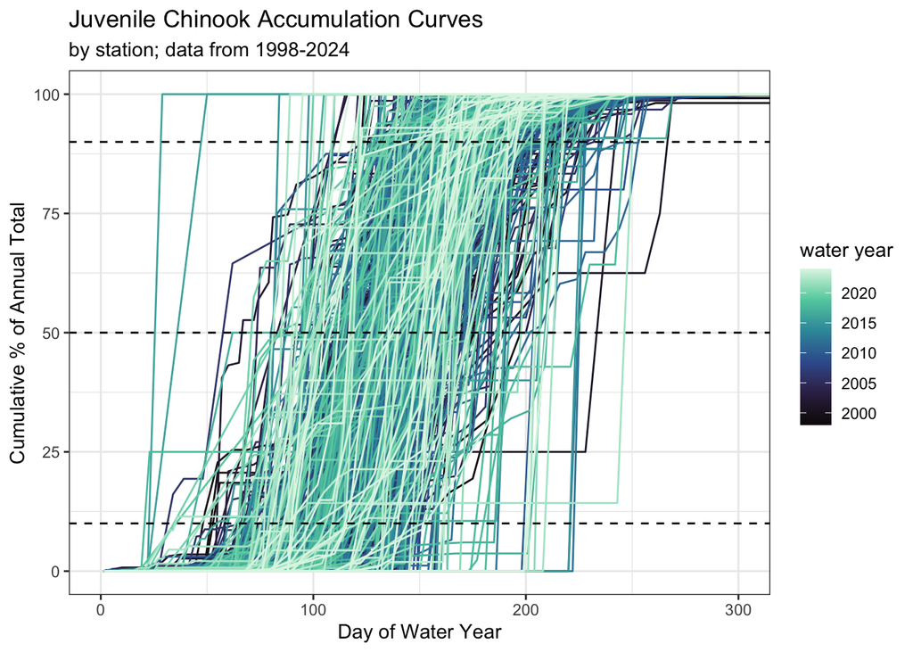

```r
# these don't offer a lot!
# annual (whole year) accumulation curves
daily_site %>%
  filter(wy >= 1998) %>%
  group_by(station, wy) %>%
  arrange(wy, wyd) %>%
  mutate(
    annual_total = sum(daily_total),
    cumul_total = cumsum(daily_total),
    cumul_percent = 100 * cumul_total / annual_total
  ) %>%
  arrange(station, wy, wyd) %>%
  ggplot(aes(x = wyd,
           y = cumul_percent,
           # identify unique station*wy combos
           group = interaction(station, wy),
           color = wy)) +
  geom_line() +
  # keep the data but zoom the view
  coord_cartesian(xlim = c(0, 300)) +
  geom_hline(yintercept = c(10, 50, 90),
             linetype = "dashed") +
  scale_color_viridis_c(option = "mako") +
  labs(x = "Day of Water Year",
       y = "Cumulative % of Annual Total",
       title = "Juvenile Chinook Accumulation Curves",
       subtitle = "by station; data from 1998-2024",
       color = "water year") +
  theme_bw()
```

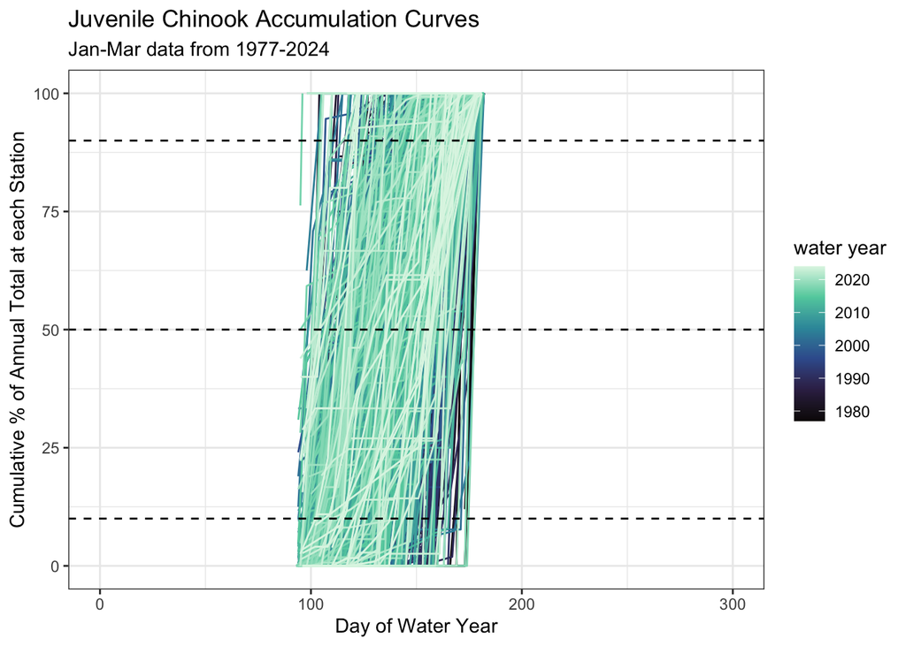

```r
# accumulation curves for Jan-Mar
daily_site %>%
  filter(wyd >= 93  & wyd <= 182) %>%
  group_by(station, wy) %>%
  arrange(wy, wyd) %>%
  mutate(
    annual_total = sum(daily_total),
    cumul_total = cumsum(daily_total),
    cumul_percent = 100 * cumul_total / annual_total
  ) %>%
  arrange(station, wy, wyd) %>%
  ggplot(aes(x = wyd,
             y = cumul_percent,
             # identify unique station*wy combos
             group = interaction(station, wy),
             color = wy)) +
  geom_line() +
  # keep the data but zoom the view
  coord_cartesian(xlim = c(0, 300)) +
  geom_hline(yintercept = c(10, 50, 90),
             linetype = "dashed") +
  scale_color_viridis_c(option = "mako") +
  labs(x = "Day of Water Year",
       y = "Cumulative % of Annual Total at each Station",
       title = "Juvenile Chinook Accumulation Curves",
       subtitle = "Jan-Mar data from 1977-2024",
       color = "water year") +
  theme_bw()
```

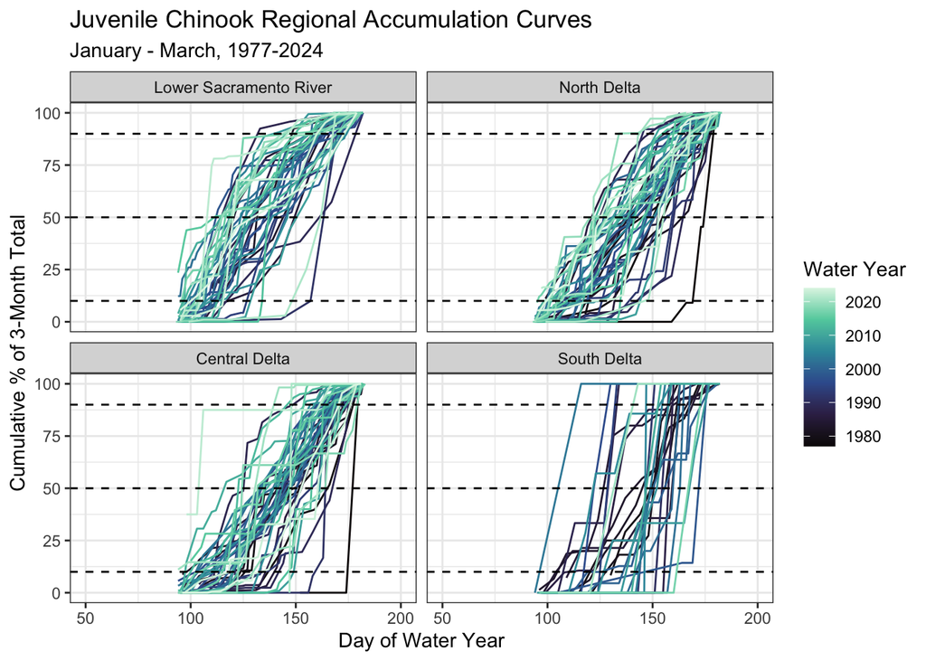

```r
regional_cumul %>%
  arrange(region_label, wy, wyd) %>%
  mutate(region_label = fct_relevel(region_label,
                                     "Lower Sacramento River", "North Delta",
                                     "Central Delta", "South Delta")) %>%
  ggplot(aes(x = wyd,
             y = cumul_percent,
             color = wy,
             group = wy)) +
  geom_line() +
  xlim(50, 200) +
  geom_hline(yintercept = c(10, 50, 90),
             linetype = "dashed") +
  scale_color_viridis_c(option = "mako") +
  labs(x = "Day of Water Year",
       y = "Cumulative % of 3-Month Total",
       title = "Juvenile Chinook Regional Accumulation Curves",
       subtitle = "January - March, 1977-2024",
       color = "Water Year") +
  facet_wrap(~region_label, nrow = 2) +
  theme_bw()
```

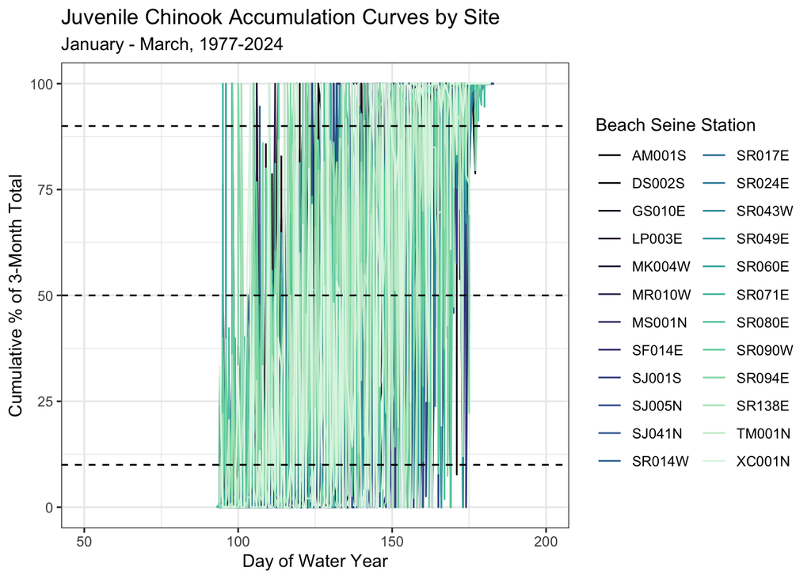

```r
site_cumul %>%
  filter(!is.nan(cumul_percent)) %>%
  arrange(station, wy, wyd) %>%
  mutate(station = as.factor(station)) %>%
  ggplot(aes(x = wyd,
             y = cumul_percent,
             color = station,
             # group = wy
             )) +
  geom_line() +
  xlim(50, 200) +
  geom_hline(yintercept = c(10, 50, 90),
             linetype = "dashed") +
  scale_color_viridis_d(option = "mako") +
  labs(x = "Day of Water Year",
       y = "Cumulative % of 3-Month Total",
       title = "Juvenile Chinook Accumulation Curves by Site",
       subtitle = "January - March, 1977-2024",
       color = "Beach Seine Station") +
  theme_bw()
```

## benchmarks

Determine the day of each water year when 10%, 50% and 90% of the total annual numbers are reached.

```r
## ID benchmarks ----
# day of water year when the 10%, 50% and 90% of total annual numbers--accumulation benchmarks

# for entire year, entire delta
annual_benchmarks <-
  daily_delta %>%
  group_by(wy) %>%
  arrange(wy, wyd) %>%
  mutate(
    annual_total = sum(daily_total),
    cumul_total = cumsum(daily_total),
    cumul_percent = 100 * cumul_total / annual_total
  ) %>%
  arrange(wy, month, wyd) %>%
  group_by(wy) %>%
  summarise(
    day_10 = min(wyd[cumul_percent >= 10]),
    day_50 = min(wyd[cumul_percent >= 50]),
    day_90 = min(wyd[cumul_percent >= 90]),
    .groups = "drop"
  ) %>%
  pivot_longer(cols = c(day_10, day_50, day_90),
               names_to = "percentile",
               values_to = "wyd") %>%
  mutate(percentile = factor(percentile))

three_month_delta_benchmarks <-
  delta_cumul %>%
  arrange(wy, wyd) %>%
  group_by(wy) %>%
  summarise(
    day_10 = min(wyd[cumul_percent >= 10]),
    day_50 = min(wyd[cumul_percent >= 50]),
    day_90 = min(wyd[cumul_percent >= 90]),
    .groups = "drop"
  ) %>%
  pivot_longer(cols = c(day_10, day_50, day_90),
               names_to = "percentile",
               values_to = "wyd") %>%
  mutate(percentile = factor(percentile))

three_month_regional_benchmarks <-
  regional_cumul %>%
  arrange(region_label, wy, wyd) %>%
  group_by(region_label, wy) %>%
  summarise(
    day_10 = min(wyd[cumul_percent >= 10]),
    day_50 = min(wyd[cumul_percent >= 50]),
    day_90 = min(wyd[cumul_percent >= 90]),
    .groups = "drop"
  ) %>%
  pivot_longer(cols = c(day_10, day_50, day_90),
               names_to = "percentile",
               values_to = "wyd") %>%
  mutate(percentile = factor(percentile),
         wy_meanCentered = wy - mean(wy))
```

## water year type

Add the water year type data (loaded previously) to the percentile data for analysis and graphics.

```r
## year type ----
# first, add water year type to the percentile_days df
wy_type <-
  read_excel(here("salmon/data/raw/cdec-water-year-type-jun-2025.xlsx")) %>%
  mutate(wy = WY,
         wyt = factor(WYT),
         watershed = factor(Area),
         .keep = "unused")

three_month_regional_benchmarks <-
  wy_type %>%
  # select Sac watershed; exclude SJR watershed
  filter(watershed == "Sacramento Valley") %>%
  # merge with benchmark data
  right_join(three_month_regional_benchmarks,
             by = "wy") %>%
  dplyr::select(-watershed) %>%
  # specify order of the wyt levels
  mutate(wyt = fct_relevel(wyt,
                           c("C", "D", "BN", "AN", "W")),
         # center wy to facilitate model convergence
         wy_meanCentered = wy - mean(wy)) %>%
  relocate(wy_meanCentered, .after = wy)

# make 'wyt' an ordered factor
three_month_regional_benchmarks <-
  three_month_regional_benchmarks %>%
  mutate(wyt = factor(wyt, levels = c("C", "D", "BN", "AN", "W"),
                      # must be low to high, where C<D<BN<AN<W
                      ordered = TRUE)) %>%
  write_rds(
    here("salmon/data/processed/three_month_regional_benchmarks.rds"))
```

## migration timing

Plot the water year days when each benchmark (10, 50, or 90%) is reach for each water year.

```r
# quick data qaqc check (shouldn't be any NAs)
unique(three_month_regional_benchmarks$region_label)
```

```
[1] Central Delta          North Delta            South Delta
[4] Lower Sacramento River
7 Levels: Central Delta Lower Sacramento River ... South Delta
```

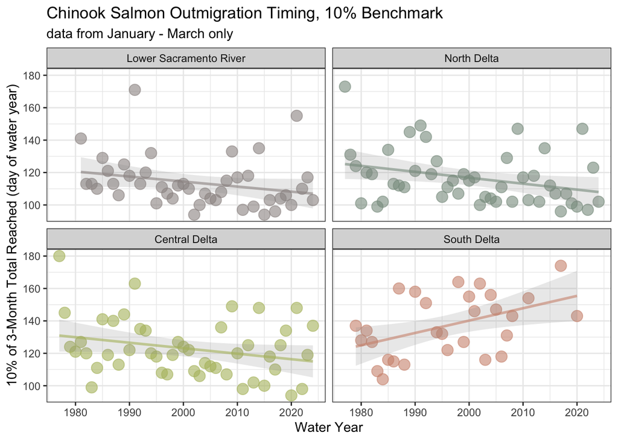

```r
# 10% benchmark
three_month_regional_benchmarks %>%
  # limit to the day_10 benchmark
  filter(percentile == "day_10") %>%
  mutate(
    # relevel region_label to establish factor order
    region_label = factor(
      region_label,
      levels = c("Lower Sacramento River",
                 "North Delta",
                 "Central Delta",
                 "South Delta")
    )
  ) %>%
  ggplot(
    aes(x = wy, y = wyd,
        # color by region
        color = region_label)
  ) +
  geom_point(size = 4) +
  # fish colors!
  scale_color_fish(discrete = TRUE,
                   option = "Oncorhynchus_tshawytscha",
                   alpha = 0.6) +
  # add trend lines
  geom_smooth(alpha = 0.2,
              method = "lm",
              se = TRUE) +
  theme_bw() +
  theme(legend.position = "none") +
  facet_wrap(~ region_label, ncol = 2) +
  labs(title = "Chinook Salmon Outmigration Timing, 10% Benchmark",
       subtitle = "data from January - March only",
       x = "Water Year",
       y = "10% of 3-Month Total Reached (day of water year)")
```

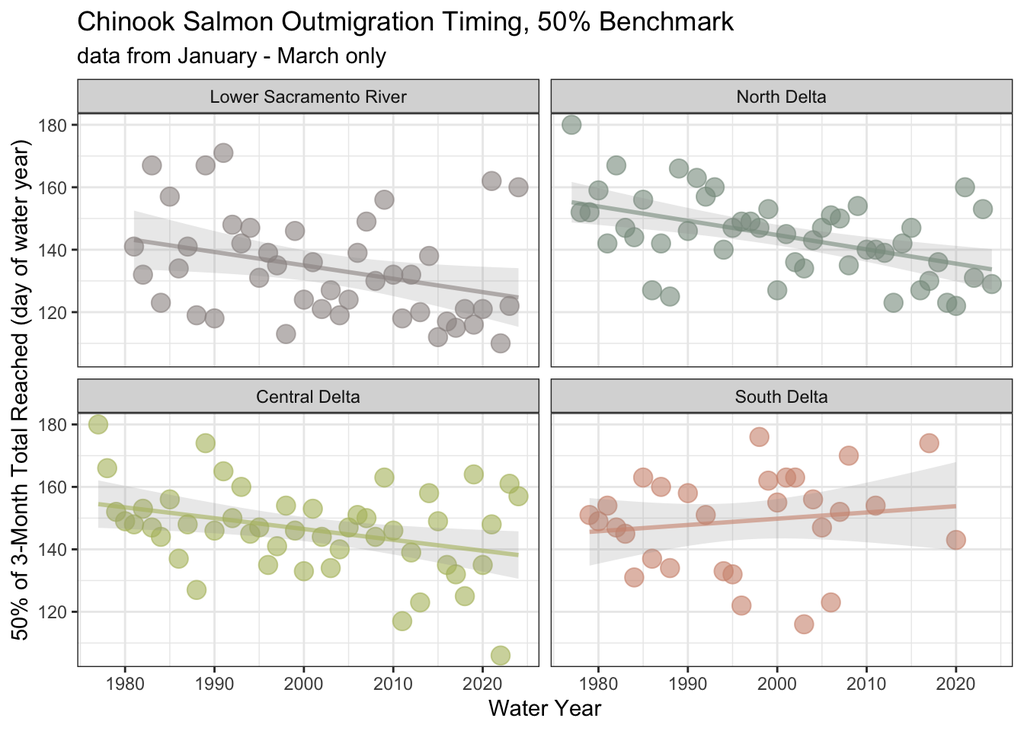

```r
ggsave(here("salmon/plots/benchmark_10pct.png"))

# 50% benchmark
three_month_regional_benchmarks %>%
  # limit to the day_50 benchmark
  filter(percentile == "day_50") %>%
  mutate(
    # relevel region_label to establish factor order
    region_label = factor(
      region_label,
      levels = c("Lower Sacramento River",
                 "North Delta",
                 "Central Delta",
                 "South Delta")
    )
  ) %>%
  ggplot(
    aes(x = wy, y = wyd,
        # color by region
        color = region_label)
  ) +
  geom_point(size = 4) +
  # fish colors!
  scale_color_fish(discrete = TRUE,
                   option = "Oncorhynchus_tshawytscha",
                   alpha = 0.6) +
  # add trend lines
  geom_smooth(alpha = 0.2,
              method = "lm",
              se = TRUE) +
  theme_bw() +
  theme(legend.position = "none") +
  facet_wrap(~ region_label, ncol = 2) +
  labs(title = "Chinook Salmon Outmigration Timing, 50% Benchmark",
       subtitle = "data from January - March only",
       x = "Water Year",
       y = "50% of 3-Month Total Reached (day of water year)")
```

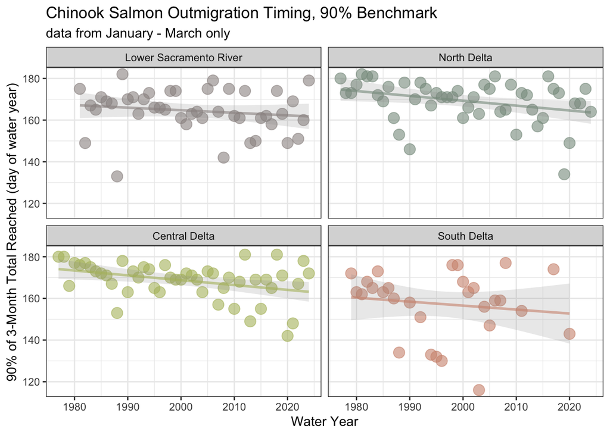

```r
ggsave(here("salmon/plots/benchmark_50pct.png"))

# 90% benchmark
three_month_regional_benchmarks %>%
  # limit to the day_90 benchmark
  filter(percentile == "day_90") %>%
  mutate(
    # relevel region_label to establish factor order
    region_label = factor(
      region_label,
      levels = c("Lower Sacramento River",
                 "North Delta",
                 "Central Delta",
                 "South Delta")
    )
  ) %>%
  ggplot(
    aes(x = wy, y = wyd,
        # color by region
        color = region_label)
  ) +
  geom_point(size = 4) +
  # fish colors!
  scale_color_fish(discrete = TRUE,
                   option = "Oncorhynchus_tshawytscha",
                   alpha = 0.6) +
  # add trend lines
  geom_smooth(alpha = 0.2,
              method = "lm",
              se = TRUE) +
  theme_bw() +
  theme(legend.position = "none") +
  facet_wrap(~ region_label, ncol = 2) +
  labs(title = "Chinook Salmon Outmigration Timing, 90% Benchmark",
       subtitle = "data from January - March only",
       x = "Water Year",
       y = "90% of 3-Month Total Reached (day of water year)")
```

```r
ggsave(here("salmon/plots/benchmark_90pct.png"))
```

## models

### change over time and water year type effects

Testing for potential effects of water year (i.e., change over time), water year type, regional differences, and differences in the three benchmarks (is there a difference in the slopes).

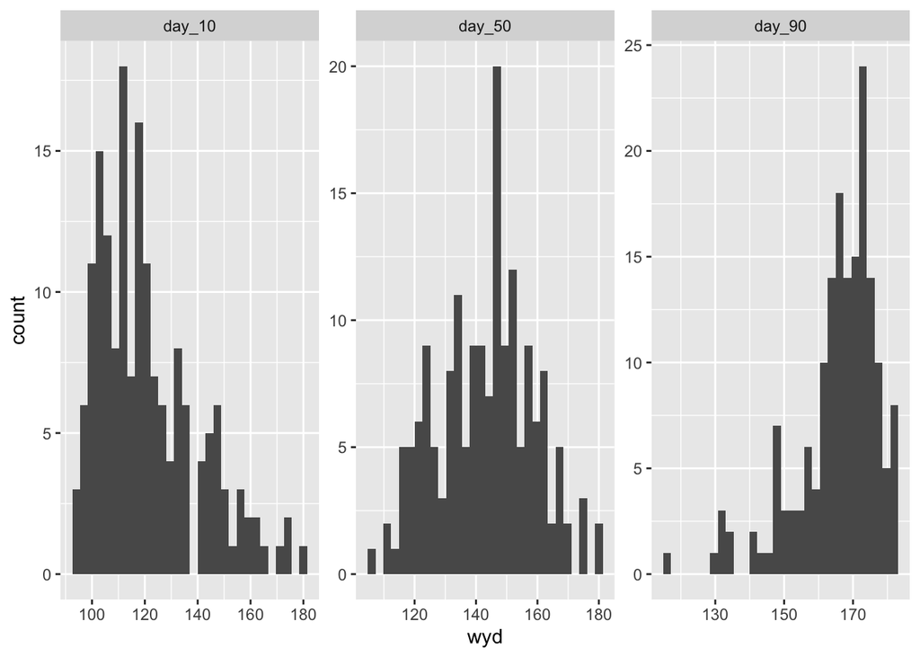

```r
# ensure that we've got a nested directory
# output_dir <- here("salmon", "results")
# if (!dir.exists(output_dir)) dir.create(output_dir, recursive = TRUE)

# I've used a Gaussian distribution (at least for now) because the distributions
# for each benchmark look "normalish." See
three_month_regional_benchmarks %>%
  ggplot(aes(wyd)) +
  geom_histogram(bins = 30) +
  facet_wrap(~ percentile, scales = "free")
```

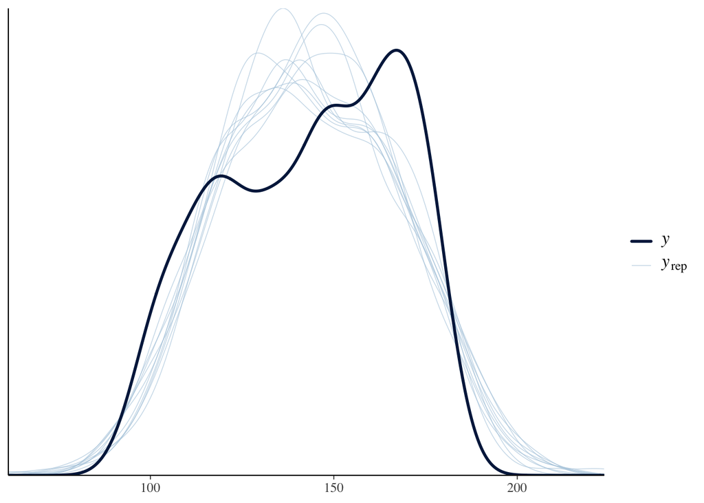

```r
# I'll do a pp_check of the model; if this shows the model giving wyd=60 or wyd=250 with
# non-trivial probabilities, I'll have to swtich to Beta or truncated normal distribution

bmod1 <-
  brm(data = three_month_regional_benchmarks %>%
        rename(region = region_label),
      family = gaussian,
      wyd ~ 1 + wy_meanCentered * percentile + wy_meanCentered * mo(wyt) + region,
      # specify parameters for executing the Markov chains
      iter = 2000, warmup = 1000, chains = 4, cores =4,
      # set seed
      seed = 42,
      # brms automatically appends '.rds'
      file = here("salmon/results/bmod1"),
      file_refit = "on_change"
      )

pp_check(bmod1) # looks good!
```

```r
(bmod1_sum <- summary(bmod1)) # see analysis
```

```
 Family: gaussian
  Links: mu = identity
Formula: wyd ~ 1 + wy_meanCentered * percentile + wy_meanCentered * mo(wyt) + region
   Data: three_month_regional_benchmarks %>% rename(region  (Number of observations: 507)
  Draws: 4 chains, each with iter = 2000; warmup = 1000; thin = 1;
         total post-warmup draws = 4000

Regression Coefficients:
                                 Estimate Est.Error l-95% CI u-95% CI Rhat
Intercept                          125.86      1.76   122.39   129.37 1.00
wy_meanCentered                     -0.44      0.10    -0.64    -0.24 1.00
percentileday_50                    21.79      1.60    18.68    24.93 1.00
percentileday_90                    44.66      1.58    41.61    47.74 1.00
regionLowerSacramentoRiver          -8.12      1.77   -11.57    -4.69 1.00
regionNorthDelta                    -2.59      1.74    -5.90     0.89 1.00
regionSouthDelta                     0.89      2.02    -3.10     4.80 1.00
wy_meanCentered:percentileday_50    -0.09      0.12    -0.32     0.15 1.00
wy_meanCentered:percentileday_90     0.13      0.12    -0.11     0.36 1.00
mowyt                               -1.01      0.41    -1.81    -0.21 1.00
mowyt:wy_meanCentered                0.09      0.03     0.03     0.15 1.00
                                 Bulk_ESS Tail_ESS
Intercept                            4661     2886
wy_meanCentered                      4144     2882
percentileday_50                     6029     3090
percentileday_90                     5999     3056
regionLowerSacramentoRiver           5117     3144
regionNorthDelta                     5039     3245
regionSouthDelta                     5341     3126
wy_meanCentered:percentileday_50     4827     2834
wy_meanCentered:percentileday_90     4791     2862
mowyt                                4710     2995
mowyt:wy_meanCentered                5175     3092

Monotonic Simplex Parameters:
                          Estimate Est.Error l-95% CI u-95% CI Rhat Bulk_ESS
mowyt1[1]                     0.23      0.17     0.01     0.63 1.00     4622
mowyt1[2]                     0.27      0.19     0.01     0.71 1.00     5195
mowyt1[3]                     0.24      0.18     0.01     0.67 1.00     6574
mowyt1[4]                     0.26      0.18     0.01     0.68 1.00     5555
mowyt:wy_meanCentered1[1]     0.13      0.11     0.00     0.41 1.00     4242
mowyt:wy_meanCentered1[2]     0.28      0.19     0.01     0.71 1.00     5122
mowyt:wy_meanCentered1[3]     0.27      0.20     0.01     0.73 1.00     6051
mowyt:wy_meanCentered1[4]     0.32      0.20     0.02     0.74 1.00     5847
                          Tail_ESS
mowyt1[1]                     2329
mowyt1[2]                     2211
mowyt1[3]                     2435
mowyt1[4]                     2732
mowyt:wy_meanCentered1[1]     2058
mowyt:wy_meanCentered1[2]     2386
mowyt:wy_meanCentered1[3]     2785
mowyt:wy_meanCentered1[4]     2335

Further Distributional Parameters:
      Estimate Est.Error l-95% CI u-95% CI Rhat Bulk_ESS Tail_ESS
sigma    14.62      0.47    13.73    15.58 1.00     6251     2773

Draws were sampled using sampling(NUTS). For each parameter, Bulk_ESS
and Tail_ESS are effective sample size measures, and Rhat is the potential
scale reduction factor on split chains (at convergence, Rhat = 1).
```

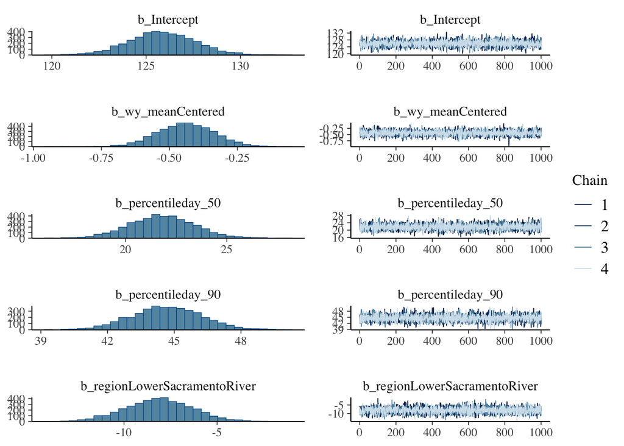

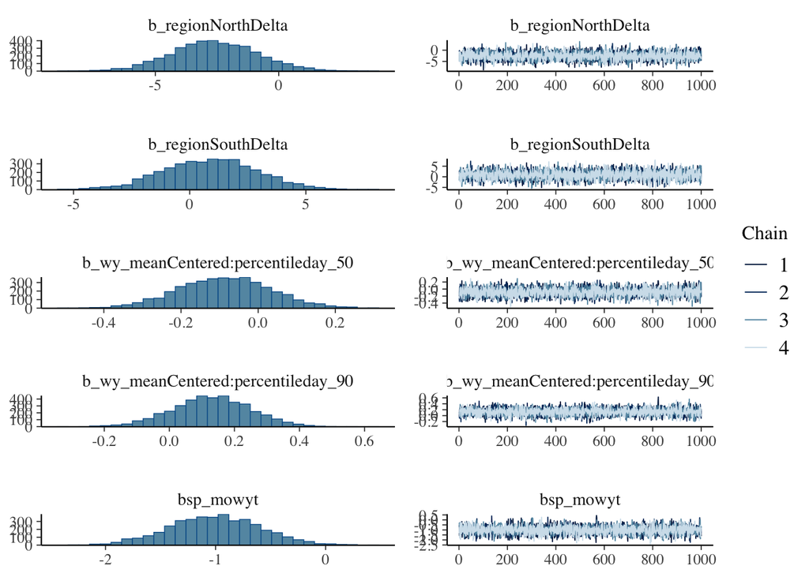

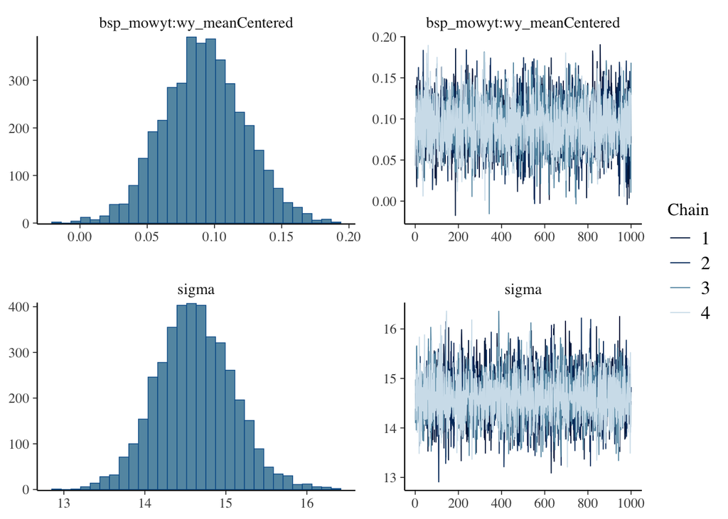

```r
plot(bmod1) # looks good
```

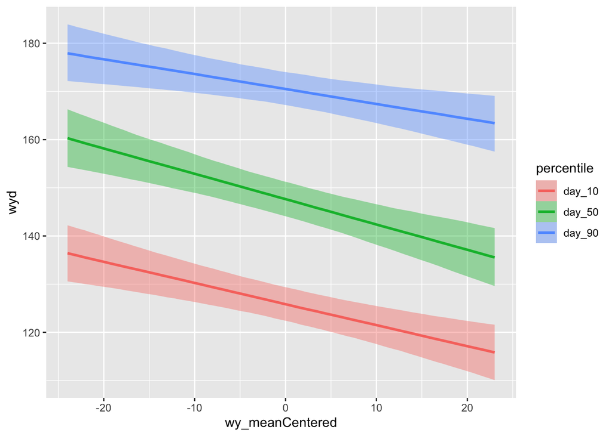

```r
conditional_effects(bmod1, "wy_meanCentered:percentile") # plot doesn't add much
```

All `Rhat = 1.00`, so the model converged cleanly. We have effective sample sizes in the low thousands and `n = 507`, so we can take the estimates seriously.

Without going into the output details here (I will with the best model), the entire distribution of the `wyd` benchmarks (10th, 50th, 90th percentiles) is moving more than 0.4 days earlier each year, and the shift is statistically credible. The three benchmarks are shifting in parallel rather than diverging or converging. Fish arrive in the Lower Sacramento River about a week prior to their arrival in the Delta, and timing to reach sites within the Delta are indistinguishable from each other. Arrival times are slightly earlier during wet years than in dry years, but that gap has narrowed over time. However, water year hydrology is genuinely heavy-tailed — ENSO events and atmospheric rivers can produce years that are extreme outliers relative to the typical range (see the accumulation curves for 1977 above for example), and I don’t want those years unduly affecting my coefficient estimates. A Gaussian model will try harder to accommodate outliers by distorting the fitted mean, whereas a Students t-distribution is more robust to these extreme values and less likely to overfit the model.

I ran the same model using a Students t-distribution (`bmod2`, below):

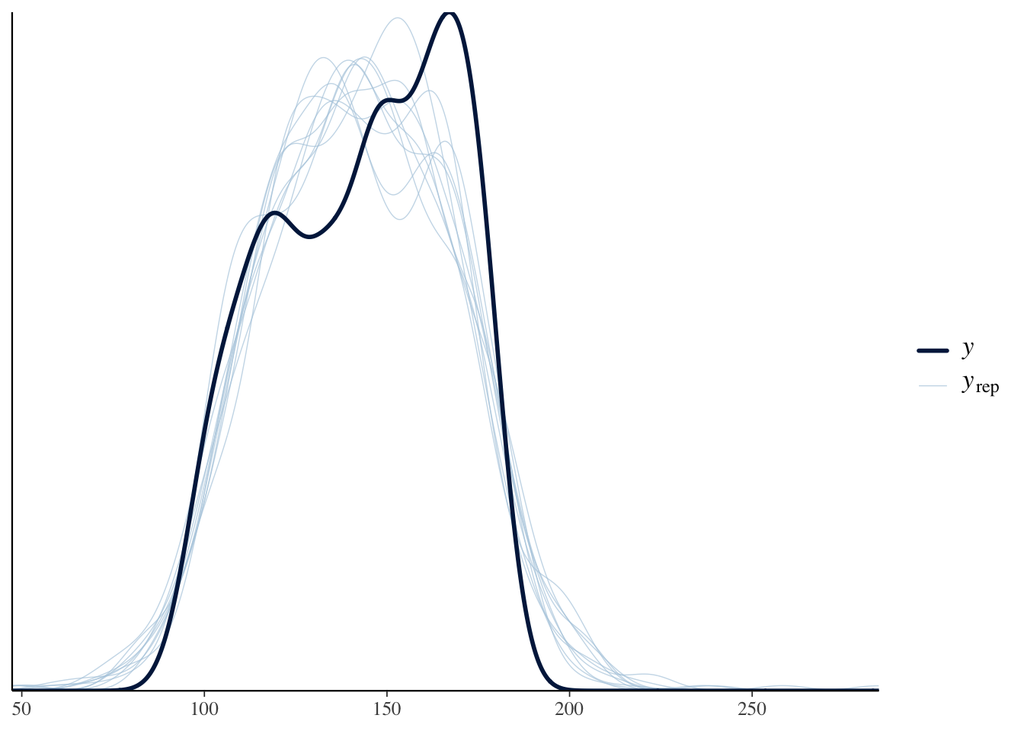

```r
bmod2 <-
  brm(data = three_month_regional_benchmarks %>%
        rename(region = region_label),
      family = student,
      wyd ~ 1 + wy_meanCentered * percentile + wy_meanCentered * mo(wyt) + region,
      iter = 2000, warmup = 1000, chains = 4, cores = 4,
      seed = 42,
      file = here("salmon/results/bmod2"),
      file_refit = "on_change"
      )

pp_check(bmod2) # looks good!
```

```r
(bmod2_sum <- summary(bmod2)) # see analysis
```

```
 Family: student
  Links: mu = identity
Formula: wyd ~ 1 + wy_meanCentered * percentile + wy_meanCentered * mo(wyt) + region
   Data: three_month_regional_benchmarks %>% rename(region  (Number of observations: 507)
  Draws: 4 chains, each with iter = 2000; warmup = 1000; thin = 1;
         total post-warmup draws = 4000

Regression Coefficients:
                                 Estimate Est.Error l-95% CI u-95% CI Rhat
Intercept                          123.09      1.94   119.26   127.00 1.00
wy_meanCentered                     -0.48      0.11    -0.69    -0.26 1.00
percentileday_50                    23.86      1.64    20.62    27.16 1.00
percentileday_90                    48.17      1.78    44.54    51.57 1.00
regionLowerSacramentoRiver          -8.32      1.63   -11.46    -5.06 1.00
regionNorthDelta                    -2.29      1.64    -5.53     0.95 1.00
regionSouthDelta                     0.58      1.98    -3.21     4.40 1.00
wy_meanCentered:percentileday_50    -0.07      0.12    -0.30     0.16 1.00
wy_meanCentered:percentileday_90     0.15      0.11    -0.08     0.37 1.00
mowyt                               -0.80      0.40    -1.59    -0.03 1.00
mowyt:wy_meanCentered                0.09      0.03     0.03     0.15 1.00
                                 Bulk_ESS Tail_ESS
Intercept                            3070     2949
wy_meanCentered                      3088     2648
percentileday_50                     4392     3026
percentileday_90                     3527     3192
regionLowerSacramentoRiver           5447     3243
regionNorthDelta                     5146     3368
regionSouthDelta                     5019     3474
wy_meanCentered:percentileday_50     3525     3170
wy_meanCentered:percentileday_90     3915     3132
mowyt                                3878     3030
mowyt:wy_meanCentered                4511     3188

Monotonic Simplex Parameters:
                          Estimate Est.Error l-95% CI u-95% CI Rhat Bulk_ESS
mowyt1[1]                     0.22      0.17     0.01     0.63 1.00     4878
mowyt1[2]                     0.25      0.19     0.01     0.72 1.00     5007
mowyt1[3]                     0.24      0.18     0.01     0.66 1.00     6153
mowyt1[4]                     0.29      0.20     0.01     0.73 1.00     5978
mowyt:wy_meanCentered1[1]     0.12      0.11     0.00     0.40 1.00     4920
mowyt:wy_meanCentered1[2]     0.31      0.19     0.02     0.71 1.00     4626
mowyt:wy_meanCentered1[3]     0.23      0.18     0.01     0.66 1.00     5604
mowyt:wy_meanCentered1[4]     0.34      0.20     0.02     0.75 1.00     5000
                          Tail_ESS
mowyt1[1]                     2238
mowyt1[2]                     2545
mowyt1[3]                     3262
mowyt1[4]                     2780
mowyt:wy_meanCentered1[1]     2405
mowyt:wy_meanCentered1[2]     2299
mowyt:wy_meanCentered1[3]     2800
mowyt:wy_meanCentered1[4]     2275

Further Distributional Parameters:
      Estimate Est.Error l-95% CI u-95% CI Rhat Bulk_ESS Tail_ESS
sigma    12.35      0.81    10.78    14.04 1.00     3259     2715
nu        8.00      4.24     3.77    19.56 1.00     3101     2902

Draws were sampled using sampling(NUTS). For each parameter, Bulk_ESS
and Tail_ESS are effective sample size measures, and Rhat is the potential
scale reduction factor on split chains (at convergence, Rhat = 1).
```

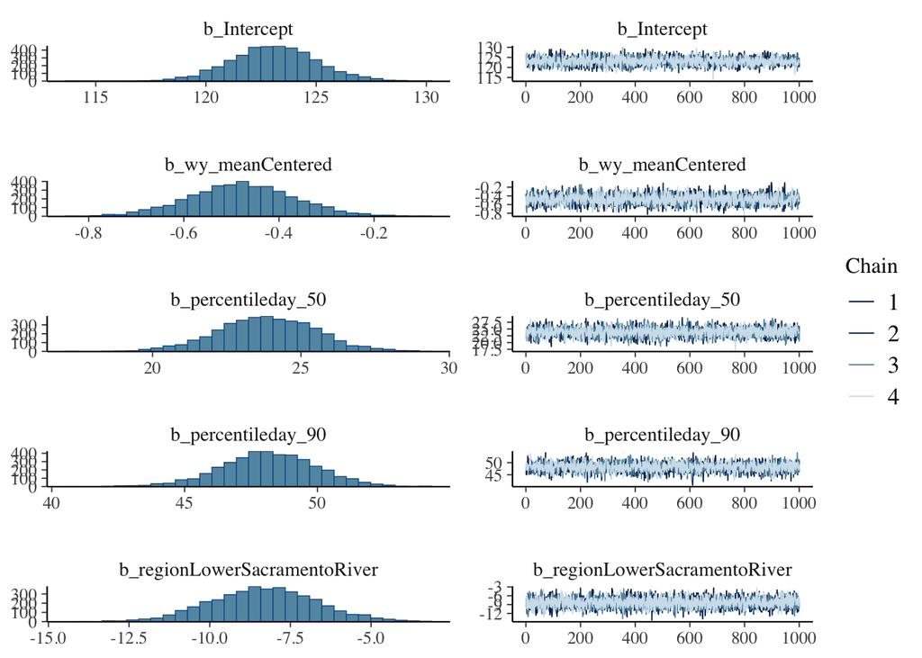

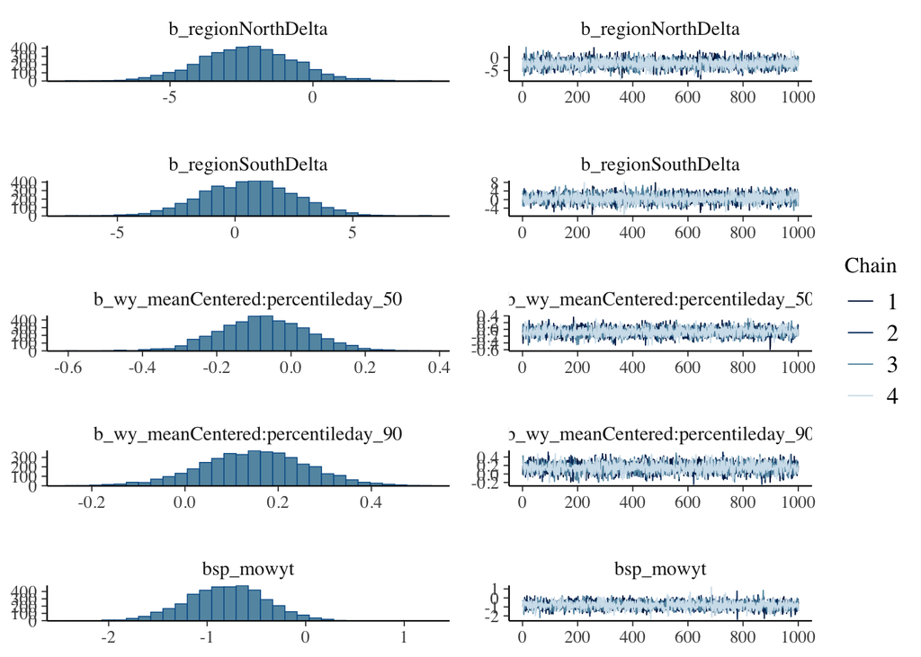

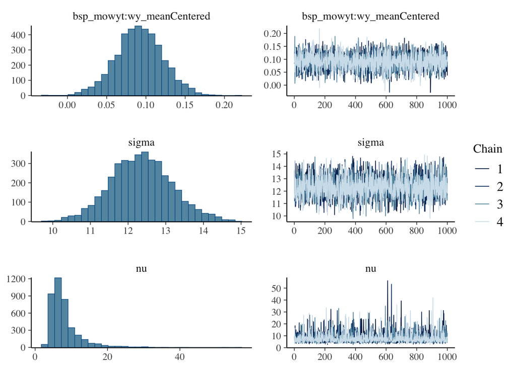

```r
plot(bmod2) # looks good
```

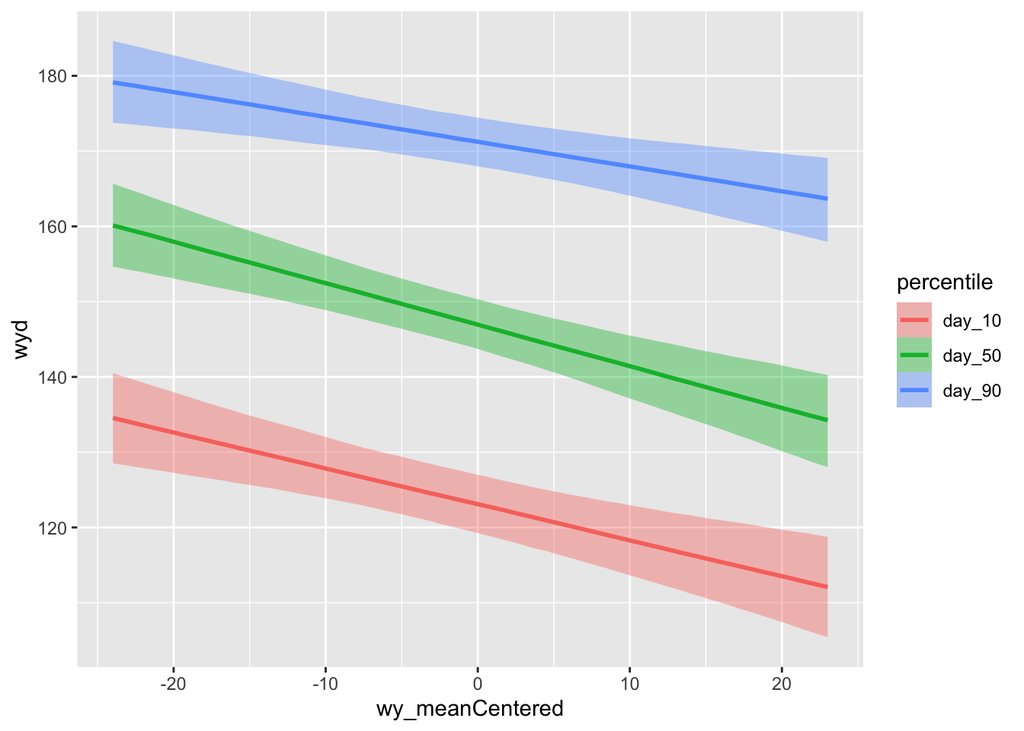

```r
conditional_effects(bmod2, "wy_meanCentered:percentile") # doesn't add much
```